# A reproducible computational framework for decoupled wildfire ignition and propagation benchmarking in the Gran Chaco (2018–2025)

D2 targets, M3/M2 inference, and an open benchmark against Canadian FWI and INPE

Published

October 27, 2026

Modified

October 27, 2026

> **Target journal:** *Computers & Geosciences* (Elsevier) — **Article type:** Research Article  
> **Peer review:** single-anonymized. Author, affiliation and repository information are provided on the title page.

# Abstract

Wildfire machine learning often suffers from spatial leakage and from the limited transferability of boreal fire-weather indices to subtropical biomes. We introduce D2, a computational target operator that formally separates primary ignition from tactical propagation, and a gated inference and evaluation framework that makes target construction, leakage control and model comparison explicit. D2 defines ignition as fire at day t with no t-1 fire within 25 km and no same-cell fire in the previous 10 days; propagation is evaluated within 25 km of a t-1 fire. A biophysical gate removes non-combustible and wet cell-days. A hybrid LightGBM model (M3) predicts ignition without t-1 fire inputs, with M2 as the fallback for cells without history and M1 as a biophysical baseline. In 2023 validation, M3 reaches ROC-AUC 0.7844/0.7628 (Chaco/Oriental), versus 0.7817/0.7496 for M2; the M1 biophysical baseline is reported in Supplementary Table S16. In 2023 development spatial blocks, M2 is the most robust model (0.6773/0.7470), and M1 does not outperform M2 on cells without history, so M1 is rejected as an operational fallback (Supplementary Tables S8 and S16). On the retrospective 2024–2025 test, M3 reaches 0.8021/0.7534 versus 0.5173/0.5564 for full Canadian FWI and 0.5389/0.4990 for INPE; propagation reaches 0.9039/0.7859. Population-level ignition precision is only 0.082 %/0.198 %, so the system is a nowcast and prioritisation tool, not a stand-alone warning system. The 2024–2025 test was already observed and is reported as retrospective, not blind. The computational contribution is the D2 operator, the gated inference policy and a reusable evaluation harness released as open software; the learner is an implementation choice, not the novelty.

**Keywords:** Wildfire nowcasting; GeoAI; reproducibility; spatial cross-validation; LightGBM; Gran Chaco.

# 1. Introduction

Vegetation fires in the South American Gran Chaco are a recurring threat to ecosystems, regional climate and public health (Baumann et al., 2017; Flannigan et al., 2009; Jolly et al., 2015). The region combines some of the fastest agricultural frontiers in South America with prolonged dry seasons and extreme heat (Alvarado et al., 2018; Pivello et al., 2021; Vallejos et al., 2015). Operational fire danger there is still largely based on fire-weather indices developed for temperate or tropical savanna systems: the Canadian Forest Fire Weather Index (FWI) (San-Miguel-Ayanz et al., 2012; Stocks et al., 1989; Van Wagner, 1987) and the INPE Risco de Fogo (Setzer et al., 2019). These indices are widely used, but they were not designed for the moisture-limited, fuel-limited and strongly anthropogenic ignition regime of the Dry Chaco. The analysis covers the continuous 2018–2025 VIIRS record over 400,006 cells, a period in which the multi-sensor VIIRS constellation (Suomi-NPP, NOAA-20 and NOAA-21) provides a comparatively consistent sampling effort.

Machine learning has become a common alternative for fire susceptibility mapping (Barmpoutis et al., 2020; Jain et al., 2020), typically with gradient-boosted trees (Ke et al., 2017). Two methodological problems limit the operational value of many published models. First, when spatial lags or t-1 fire variables enter the ignition layer, the model learns persistence rather than ignition; reported discrimination can be high while the model is unable to anticipate new ignitions (Dormann et al., 2007; Legendre, 1993; Ploton et al., 2020; Roberts et al., 2017; Tobler, 1970). Second, fire-weather indices calibrated in boreal or temperate systems do not necessarily transfer to subtropical biomes, and their failure is rarely quantified on a common retrospective test. A reproducible benchmark is therefore needed not only to compare models, but to make the target definition, the leakage controls and the evaluation protocol explicit enough to be audited.

The operational context adds a third constraint: most agencies need a daily product that can run on commodity hardware, with transparent inputs and a documented failure mode. A model that cannot be reproduced or audited is difficult to adopt even when its aggregate score is high. The framework is therefore designed around explicit targets, a frozen test and a small, inspectable software stack.

We address both problems by formalizing three reusable computational components. The learner is intentionally replaceable: (i) a D2 target operator that separates primary ignition from tactical propagation; (ii) a gated inference architecture that uses a hybrid model (M3) where fire history exists and a base model (M2) where it does not; and (iii) an evaluation harness that combines temporal holdout, spatial blocks, grouped bootstrap, lead-time and cost-loss analysis. The geoscientific contribution is a transferable, leakage-controlled benchmark: full FWI and INPE are tested under the same D2 protocol in the Gran Chaco, and the temporal versus spatial limits of the hybrid model are reported explicitly.

The novelty is computational and infrastructural: D2 formalizes the target contract, gated inference defines the operational policy, the harness makes spatial, temporal, calibration and cost-loss evidence reproducible, and the software exposes the contract to other learners. The national case study is a testbed for data-scarce subtropical regions; we do not claim universal validity. The main computational contributions are:

- **D2 target operator.** A reproducible rule that prevents persistence from being mixed with ignition and makes leakage checks explicit.
- **M3/M2 inference.** A two-stage architecture that combines biophysical screening with a hybrid ignition model and a fallback for cells without fire history.
- **Reproducible evaluation harness.** Grouped bootstrap, spatial blocks, lead-time, conformal coverage and cost-loss in one protocol.
- **Open software and data.** A zero-copy Polars/DuckDB pipeline, public code, DOIs and tests.

# 2. Computational framework

## 2.1 D2 target operator

The target operator D2 is applied to the national 1-km² grid and to all daily VIIRS observations from 2018 to 2025. For a cell i and day t:

- **Primary ignition** is a fire at (i,t) when there is no fire within 25 km at t-1 and no fire in cell i during the previous 10 days.
- **Tactical propagation** is a fire at (i,t) within 25 km of at least one fire at t-1.

The two domains are disjoint. This prevents a model from obtaining high discrimination by learning “fire continues next to yesterday’s fire” while being evaluated as an ignition model. The same operator is used for training, validation, test and alert generation. The complete sampling counts and spatial stratification are reported in Supplementary Note S1 and Table S10.

The population is sampled at a 1:10 ratio per task and region. Training uses 2018–2022, validation uses 2023 and the test is the frozen 2024–2025 period. The ignition test contains 376,552 cell-days (34,232 positives) and the propagation test contains 1,437,414 cell-days (130,674 positives). The combined task-level test therefore has 1,813,966 cell-days. The sample is case-control; population denominators are kept separately and used for prior correction. The same test rows are used for every model and for FWI/INPE, so the comparison is paired by construction.

Formally, let $F_t$ be the set of cells with a thermal detection on day $t$. D2 ignition at cell $i$ and day $t$ requires $i \in F_t$, no cell in $F_{t-1}$ within 25 km of $i$, and no detection in cell $i$ during the ten preceding days. D2 propagation requires $i \in F_t$ and at least one cell in $F_{t-1}$ within 25 km. The 25-km threshold is a domain restriction, not a negative-sampling buffer; no 20-km buffer is applied to the test sample. The buffer is used only in the spatial block holdout described below.

## 2.2 Biophysical gate and decoupled inference

A first-stage gate removes cell-days with no combustible fuel, with VPD below 0.8 kPa, or with 48-h rainfall of at least 10 mm. Gating is applied before feature construction; it reduces the inference space while retaining 97.17 % of thermal detections and removing 21.7 % of cell-days. The gate is not used as a label filter: it only removes physically implausible candidates. Water, consolidated urban surfaces and saturated fuels are therefore excluded from inference, but they remain part of the audit population used to compute retention.

Two models share the gated space. M3 is a hybrid LightGBM model with weather, fuel, ecotone, anthropogenic priors and causal historical features. It contains no t-1 fire variable. M2 is a base LightGBM model with weather, fuel, ecotone and a historical anchor. In the operational layer, M3 is used for cells with observed fire history (`freq_hist_1km > 0`) and M2 is used as a fallback for cells without history; M1 remains a biophysical baseline. The propagation layer uses a separate model with a causal kernel at t-1: distance to the nearest active fire, fire counts within 25 km and accumulated FRP. The architecture is summarized in Figure 1.

M1 uses 24 weather and fuel variables, M2 adds the ecotone and a 25-km historical anchor (35 variables), and M3 adds local density, annual-cycle and accessibility terms (44 variables in Chaco and 45 in Oriental). The feature families are deliberately separated: M3 receives no t-1 fire variable, whereas propagation receives only causal t-1 fire information. This separation makes the ablation interpretable and prevents the fallback from becoming a hidden persistence model. M3 groups meteorology (maximum and minimum temperature, thermal range, VPD, wind, 48-h rainfall, consecutive dry days, FFMC and ISI), fuel fractions (pasture, savanna, dry forest, humid forest and wetland/palm), ecotone, civil calendar and burning season, accessibility corridors, local density at 5 and 10 km, and causal recurrence. M1 contains only the meteorological and fuel subsets. The feature lists are frozen in the code release. The fallback rule is evaluated on cells with `freq_hist_1km = 0`; M2 is the validated fallback and M1 is retained only as a diagnostic baseline.

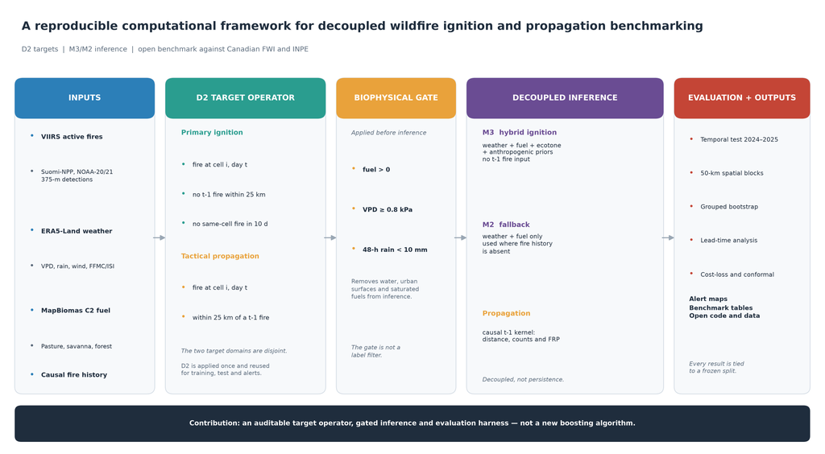

Figure 1: Computational framework: multi-source inputs, D2 target operator, biophysical gate, decoupled M3/M2 ignition and t-1 propagation, reproducible evaluation and open outputs.

Probabilities are calibrated with a monotonic bounded Platt transform. The monotonic constraint preserves the ranking of the tree ensemble while preventing the slope inversion that can occur under severe class imbalance (Niculescu-Mizil & Caruana, 2005; Platt, 1999). The calibration is fitted on 2023 and frozen for the 2024–2025 test. Calibration details, including the monotonicity proof and the full hyperparameter table, are in Supplementary Note S2 and Table S2.

The same calibration and cutoff logic is used for M1, M2, M3 and propagation. Cutoffs are selected on validation with an F0.5 criterion and then frozen. The operational alert applies the cutoff after prior correction, not before; otherwise the population prevalence would change the ranking threshold. This distinction is important because a cutoff that looks conservative on a 1:10 sample can be extremely permissive at population prevalence.

## 2.3 Reproducible evaluation harness

The evaluation harness is part of the computational contribution. It contains five components:

1. A strictly temporal split: training 2018–2022, validation 2023, test 2024–2025.
2. A spatial block holdout of 50 km with a 20-km buffer, used to separate temporal from spatial generalization.
3. A paired bootstrap grouped by date (`B = 1,000`) for confidence intervals and differences against FWI and INPE.
4. A lead-time evaluation using t-1 weather to quantify the nowcast-to-forecast gap.
5. A population-level and cost-loss evaluation to move beyond case-control precision.

## 2.4 Data and implementation

The grid contains 400,006 cells of 1 km² in UTM zone 21S. Daily inputs are VIIRS 375 m active fire detections from Suomi-NPP, NOAA-20 and NOAA-21; ERA5-Land 3-hourly meteorology aggregated to daily values; annual MapBiomas Collection 2 maps (2017–2023), joined to each row with the prior-year map; and causal historical priors built with a monthly cutoff and a rolling three-year window. Raw data are public but are not redistributed; processed data and trained models are archived with a DOI.

The pipeline uses a deterministic integer `cell_id`, a NumPy lookup in O(1), and columnar joins in Polars and DuckDB. A spatial join of 50,000 points is shown only as a reference; the operational lookup avoids point-in-polygon at inference. The full pipeline processes 400,006 cells in 1.569 s with 2,182.1 MB peak RAM on ARM64; x86_64 was not measured. The study domain and regional split are shown in Figure 2; the per-stage profile is in Supplementary Table S4.

Data quality checks are part of the pipeline: duplicate VIIRS overpasses are collapsed, `low` confidence detections are removed, daily precipitation is reconstructed from sub-daily increments and impossible values above 300 mm/day are rejected. ERA5-Land nodes are mapped to cells with a precomputed cKDTree. The processed archive contains the test targets, model probabilities, benchmark layers, sampling plan and trained artifacts, so the result tables can be regenerated without downloading the full raw archive. The complete data dictionary and checks are in Supplementary Note S1 and Table S15. The repository includes 76 unit tests, a pinned dependency file, a continuous-integration workflow and a public GitHub release. The test suite covers target definitions, VIIRS filtering, climate aggregation, monotonic calibration, metrics and the alert layer; it can run without downloading the raw archive. This separation between a reproducible evaluation package and the full raw-data pipeline is deliberate: reviewers can audit the tables without a multi-terabyte download, while the canonical scripts remain available for a full rebuild.

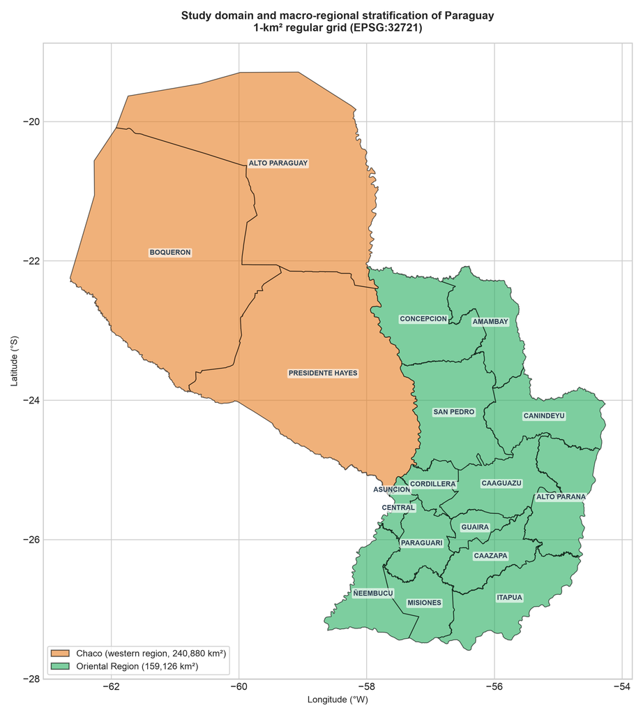

Figure 2: Study domain and regional split: Dry Chaco (west) and Oriental Region (east) over the national 1-km² grid.

# 3. Results

## 3.1 Selection on 2023 validation and retrospective test

Model selection used only the 2023 validation set and the 2023 development spatial holdout. The 2024–2025 test was not used to select the model, variables or thresholds. Table 1 summarises temporal validation.

Table 1: 2023 temporal validation (1:10 case-control). Selection was frozen before the 2024–2025 test was evaluated. The M1 baseline is reported in Supplementary Table S16.

| Region | Model | ROC-AUC | PR-AUC | F0.5 |
| --- | --- | --- | --- | --- |
| Chaco | M2 base | 0.7817 | 0.2452 | 0.2933 |
| Chaco | M3 hybrid | 0.7844 | 0.2542 | 0.2979 |
| Oriental | M2 base | 0.7496 | 0.2221 | 0.2631 |
| Oriental | M3 hybrid | 0.7628 | 0.2441 | 0.2875 |

The paired M3 − M2 difference was +0.0028 [+0.0001, +0.0054] ROC-AUC and +0.0089 [+0.0034, +0.0144] PR-AUC in Chaco, and +0.0132 [+0.0097, +0.0169] and +0.0221 [+0.0166, +0.0272] in Oriental (grouped-by-date bootstrap, B = 1,000). With the pre-specified margin δ = 0.01, M3 is retained in both regions. In 2023 spatial blocks, M2 was the most robust model (0.6773/0.7470), ahead of M3 (0.6496/0.7277). M1 was evaluated as a diagnostic baseline and did not outperform M2 on cells without history; M1 is therefore rejected as the operational fallback (Supplementary Tables S8 and S16). The final architecture is M3 for cells with history and M2 for cells without history.

Table 2 reports the retrospective 2024–2025 test. M3 reaches ROC-AUC 0.8021 in Chaco and 0.7534 in Oriental. Propagation reaches 0.9039/0.7859. Case-control F0.5 precision is 32.82 %/30.13 % for ignition and 83.69 %/65.03 % for propagation. These are sample-level metrics; they are not operational precision.

Table 2: Retrospective D2 test (2024–2025; 1,813,966 task cell-days in total: 376,552 ignition and 1,437,414 propagation). Precision and recall are case-control (9.09 % prevalence) at the F0.5 cutoff. The test was already observed and is not used for selection. Population metrics are in Supplementary Table S6.

| Region | Model | ROC-AUC [95 % CI] | PR-AUC | Precision (%) | Recall (%) | FP |
| --- | --- | --- | --- | --- | --- | --- |
| Chaco | M3 ignition | 0.8021 [0.797–0.807] | 0.2842 | 32.82 | 30.30 | 9,960 |
| Chaco | M2 ignition | 0.7991 [0.794–0.805] | 0.2766 | 33.28 | 27.26 | 8,773 |
| Chaco | Propagation | 0.9039 [0.899–0.909] | 0.6935 | 83.69 | 52.40 | 5,353 |
| Oriental | M3 ignition | 0.7534 [0.747–0.759] | 0.2340 | 30.13 | 18.59 | 7,835 |
| Oriental | M2 ignition | 0.7406 [0.735–0.746] | 0.2146 | 26.09 | 19.59 | 10,075 |
| Oriental | Propagation | 0.7859 [0.779–0.794] | 0.3752 | 65.03 | 19.84 | 8,351 |

Population-level ignition precision is 0.082 % in Chaco and 0.198 % in Oriental. Propagation precision is 9.67 % and 4.78 %. These are the operationally relevant values and are much lower than the case-control values. Relative to prevalence, ignition precision is about 5.4× and 4.8× above chance, while propagation precision is about 62× and 23× above chance. Absolute precision remains low; the model is therefore a prioritisation and nowcast layer, not a stand-alone alert system.

On the retrospective test, M3 does not uniformly dominate M2. In Chaco, M3 improves ROC-AUC and PR-AUC, but M2 has slightly higher precision and fewer false positives; in Oriental, M3 improves precision and reduces false positives, with lower recall. The gain is a trade-off, not a universal superiority. By year, M3 keeps ROC-AUC 0.8030/0.8011 in Chaco and 0.7532/0.7539 in Oriental for 2024/2025; propagation falls from 0.9069 to 0.8982 in Chaco and from 0.7911 to 0.7785 in Oriental. 2024 uses the 2023 fuel map with lag 1 and 2025 uses 2023 with lag 2; metrics are therefore reported separately rather than as a single average.

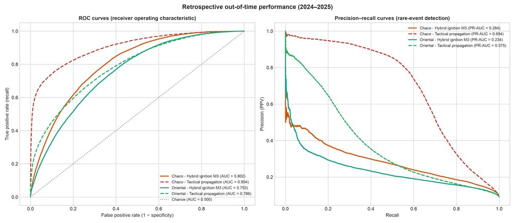

Figure 3: ROC and precision–recall curves for the retrospective D2 test (2024–2025), by region and task. The ignition curves correspond to M3; propagation uses the causal t-1 layer.

## 3.2 Benchmark against FWI and INPE

Table 3 compares M3 with full FWI and INPE on the same retrospective test. M3 exceeds FWI by ΔROC = +0.2848 in Chaco and +0.1970 in Oriental, and INPE by +0.2633 and +0.2544. All paired comparisons have p ≤ 0.001 with B = 1,000. The full benchmark, including M2 and propagation rows, is in Supplementary Table S11; the complete significance table is in Supplementary Table S7.

Table 3: Benchmark on the retrospective 2024–2025 test. ΔROC is M3 minus the reference. FWI and INPE are normalized indices, not calibrated probabilities. The full table is Supplementary Table S11.

| Region | Model | ROC-AUC | PR-AUC | ΔROC vs M3 | p |
| --- | --- | --- | --- | --- | --- |
| Chaco | M3 ignition | 0.8021 | 0.2842 | — | — |
| Chaco | Full Canadian FWI | 0.5173 | 0.0957 | +0.2848 | ≤0.001 |
| Chaco | INPE Risco de Fogo | 0.5389 | 0.1031 | +0.2633 | ≤0.001 |
| Oriental | M3 ignition | 0.7534 | 0.2340 | — | — |
| Oriental | Full Canadian FWI | 0.5564 | 0.1061 | +0.1970 | ≤0.001 |
| Oriental | INPE Risco de Fogo | 0.4990 | 0.0908 | +0.2544 | ≤0.001 |
| Chaco | Climatological baseline | 0.5000 | 0.0909 | +0.3021 | — |
| Oriental | Climatological baseline | 0.5000 | 0.0909 | +0.2534 | — |

Figure 4 shows the corresponding ROC and precision–recall curves. The canonical indices are close to the diagonal in Chaco; in Oriental they are also weak and do not improve materially over a climatological baseline. Full FWI has ROC-AUC 0.5173/0.5564 and INPE 0.5389/0.4990; neither is competitive with M3 on the same retrospective dates. The result is not a claim that the indices are universally invalid, but that their transfer to this subtropical system is not supported. FWI and INPE are normalized danger indices, so their apparent operating point depends strongly on the cutoff chosen on validation. In Chaco, full FWI reaches high recall only at very low precision, while INPE is conservative in both regions; neither behavior translates into a competitive ranking. PR-AUC values are close to the 0.09 case-control baseline, which means that the indices add little discrimination beyond chance on these retrospective dates.

The controlled ablation confirms that socio-ecological variables improve ranking, especially in Oriental. With the same capacity (45/60 rounds and 23/31 leaves), M2 reaches 0.7991/0.7406 and M3 0.8021/0.7534; M1 is the lowest in both regions. The M3 − M2 gain is +0.0030/+0.0128 ROC-AUC and +0.0076/+0.0194 PR-AUC. In Chaco, M3 precision is 32.81 % versus 33.27 % for M2; in Oriental it is 30.13 % versus 26.09 %. The advantage is not uniform and is not presented as a precision gain in both regions. The complete ablation table is Supplementary Table S12. TreeSHAP identifies historical distance, dry-forest fraction, accessibility and seasonality as the dominant drivers in Chaco; in Oriental, historical distance and local anthropic concentration dominate. The complete SHAP table and figure are Supplementary Table S13 and Supplementary Figure S1. This does not establish causality, but it shows that the model is not relying on a single weather variable.

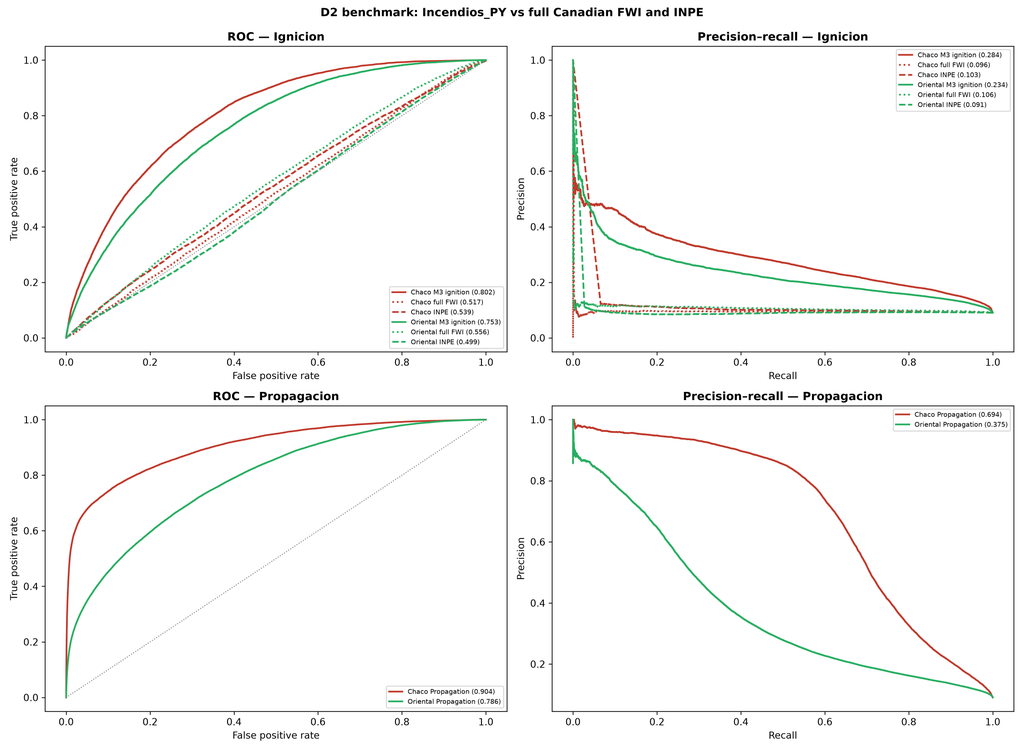

Figure 4: ROC and precision–recall curves for M3 against full Canadian FWI and INPE under D2.

## 3.3 Temporal and spatial generalization

The M3 advantage is temporal, not spatial. In the 50-km block holdout with a 20-km buffer evaluated in 2023, M2 reaches 0.6773 in Chaco and 0.7470 in Oriental, and M3 reaches 0.6496 and 0.7277; M1 is reported in Supplementary Table S8. M2 is the most robust model in unseen blocks. M3 falls from 0.7821 on held-in cells to 0.6496 in the Chaco holdout, and from 0.7473 to 0.7277 in Oriental; M2 falls from 0.7832 to 0.6773 in Chaco but improves from 0.7365 to 0.7470 in Oriental. M1 is more stable, but its absolute level is lower (Supplementary Table S8). Table 4 reports the compact comparison; the full block table and design are in Supplementary Table S8.

Table 4: Development spatial block validation with 50-km blocks and a 20-km buffer, evaluated in 2023. Held-in values are the reference for cells not excluded from training. Full results, including M1, are in Supplementary Table S8.

| Region | Model | Held-in ROC-AUC | Holdout ROC-AUC | Holdout PR-AUC |
| --- | --- | --- | --- | --- |
| Chaco | M2 base | 0.7832 | 0.6773 | 0.1760 |
| Chaco | M3 hybrid | 0.7821 | 0.6496 | 0.1630 |
| Oriental | M2 base | 0.7365 | 0.7470 | 0.1820 |
| Oriental | M3 hybrid | 0.7473 | 0.7277 | 0.1608 |

The spatial design retains 44 blocks and excludes a 20-km buffer around holdout cells during training; priors are recomputed without held-out fires. The gap between held-in and holdout performance measures spatial memorization. M3 shows a large drop in Chaco and a smaller drop in Oriental; M2 retains the best absolute discrimination in both regions. The result does not support M3 as a spatial extrapolator, and it does not make M1 the best option: M1 was a stable but lower baseline and was rejected as the operational fallback. The full M1 spatial and no-history results are in Supplementary Tables S8 and S16; the M3/M2 architecture follows that evidence.

With t-1 weather, M3 retains 0.7831/0.7613 and M2 0.7818/0.7463; M1 is lower and is reported in Supplementary Table S9. The small M3 drop shows that recurrence priors, not same-day weather, dominate the hybrid signal. This is why the current system is a nowcast/hindcast; a real day-ahead system would require forecast weather. Lead-time details are in Supplementary Table S9.

## 3.4 Operational utility

The cost-loss analysis is sobering for ignition: M3 does not clearly outperform M2, and in the Chaco M2 is slightly better at the optimum. The propagation layer does show value near α = 0.002. The full cost-loss table and curves are in Supplementary Table S14 and Supplementary Figure S3. The operational product therefore prioritises propagation and uses ignition as a screening layer.

Cost-loss is defined as the expected value of issuing an alert when the cost of a false alarm is $C$ and the loss avoided by a true alert is $L$; the ratio $\alpha=C/L$ is varied from 0 to 0.5. This is a deliberately simple decision model, not an estimate of agency budgets. It is useful because it exposes the regime in which a probabilistic layer has value. For ignition, the curves are almost flat near zero; for propagation, the value is concentrated at small $\alpha$. The result supports the operational choice of prioritising propagation and treating ignition as a screening layer.

Conformal coverage is empirical: 89.85 %/90.19 % for a nominal 90 % level and 95.02 %/94.56 % for 95 %. These values are close to nominal but do not constitute a formal guarantee under temporal shift. The result is still useful because it shows that the calibration layer is not grossly overconfident. A reliability diagram and the full conformal table are in Supplementary Table S5.

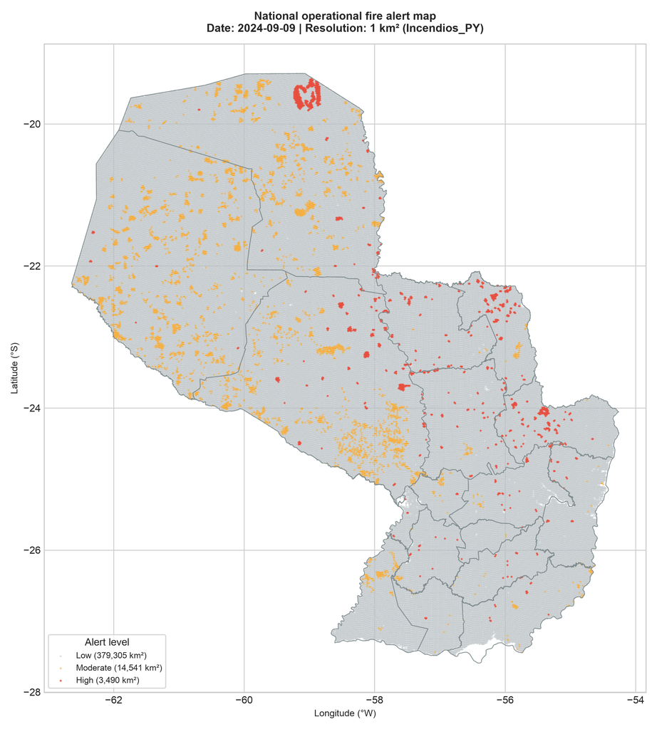

Figure 5: National 1-km² alert map for 2024-09-09, showing the spatial distribution of low, moderate and high alert cells.

## 3.5 Reproducibility checks

The code and data releases are part of the result. The repository contains the target operator, the frozen evaluation scripts, the trained boosters and calibrators, the generated tables and a pinned environment. A clean-environment run of the 76 unit tests covers target construction, VIIRS filtering, climate aggregation, monotonic calibration, metrics and alert routing. The data archive contains the test targets and model probabilities, so the main tables can be regenerated without the raw multi-terabyte archive. The full raw-data pipeline remains available for a complete rebuild.

Two practical checks are worth reporting. First, the test split is frozen and the cutoff is selected on validation; no test row is used for model selection. Second, the calibration and conformal layers are fitted before the test and never updated. These checks do not eliminate distribution shift, but they remove the most common sources of optimistic bias. The tables in this manuscript are regenerated from the repository and correspond to release v2.0.0; the code and data concept DOIs are reported in the Code and Data Availability sections.

# 4. Discussion

## 4.1 Why canonical indices fail

Full FWI and INPE are weak in both regions. The Chaco is moisture-limited and fuel-limited at the same time: fine fuels cure quickly under high VPD, but ignition depends on human access, pasture management and fire history. A single weather index cannot represent that interaction. In the Oriental Region, the signal is more anthropogenic and less dependent on same-day weather. These results do not imply that FWI or INPE are useless globally; they show that their transfer to this subtropical system is not supported by the retrospective test.

The regional asymmetry is informative. In the Chaco, the dominant land-cover contrast is between dry forest, pastures and natural grasslands; fire is often a management tool in a matrix with high fuel connectivity. In the Oriental Region, the landscape is wetter and more fragmented, and ignition is tightly coupled to roads, farms and the agricultural calendar. The same hybrid architecture therefore operates under different causal regimes, and the SHAP rankings reflect that difference: dry-forest fraction is important in the Chaco, while local anthropic concentration is more important in Oriental. A model with a single set of regional weights would blur this contrast.

The weak FWI/INPE performance also has a practical implication: switching to a “better index” is not sufficient. The input representation, the target definition and the evaluation design matter as much as the learner. The benchmark therefore compares the complete computational pipeline, not only the model class.

## 4.2 What decoupling buys and where it fails

Decoupling produces a useful diagnostic. M3 is a strong temporal nowcast for cells with history, but its advantage disappears in unseen spatial blocks. M2 is the most robust model in those blocks and also outperforms M1 on cells without history, so it replaces M1 as the fallback. This is a double result: the operational layer should not present M3 as a spatial extrapolator, and it should not retain a biophysical fallback that 2023 validation does not support.

The D2 operator is also a guard against leakage. Without it, a model can mix persistence and ignition and obtain impressive but non-operational metrics. The combination of D2, a no-t-1 ignition layer and a spatial block holdout is the main methodological contribution. It also explains why a single aggregate score is not enough: the same model can be strong on held-in cells, weak on held-out blocks and weak at population prevalence, and each of these results answers a different question. Reporting the three views separately is more informative than selecting the most favorable one.

From a software perspective, the relevant advance is not the size of the model but the auditability of the path from raw observations to a map. A single integer cell identifier, deterministic joins, frozen prevalence metadata and a pinned environment make the pipeline reproducible on a laptop. The comparison with a GeoPandas spatial join is included only to show why the integer lookup matters at national scale; it is not a benchmark of GIS libraries. The open code and data DOIs allow independent re-execution of the main tables and replacement of the model with another learner.

The framework is also intentionally bounded. It does not include a new neural architecture, a data-assimilation scheme or a full fire-spread simulator. Its contribution is to make a difficult applied problem comparable and reproducible. That is a narrower claim than a new algorithm, but it is the claim that the evidence supports.

A second lesson is that benchmark design changes the conclusion. If the test had been a random split, M3 would have looked stronger; if the ignition layer had included t-1 fire density, it would have looked stronger still. The spatial block and D2 target make those shortcuts visible. This is why the negative result is not a weakness of the paper but part of its contribution: it gives future work a clear baseline to beat without leakage.

## 4.3 Implications for computational geoscience

The framework suggests a practical division of labour for geoscientific machine learning. The learner can be replaced; the target operator, the leakage controls and the evaluation harness should not. In this sense, the contribution is a computational protocol and software infrastructure, not a new learner. That distinction matters for C&G because it makes the contribution reusable beyond Paraguay: another team can keep the D2 logic, substitute local fuel and weather layers, and compare its model on the same kind of retrospective test.

The framework also makes failure explicit. A model that is excellent on held-in cells but poor on spatial blocks is not a universal model, and a model that is only competitive on a case-control sample is not an operational system. Reporting both views is more useful than reporting a single high AUC. This is the main methodological lesson of the study, and it generalizes beyond fire: any geoscientific pipeline that combines spatial priors, temporal targets and rare events needs the same separation between ranking skill, calibration and operational prevalence.

## 4.4 Limitations

1. The study covers one country and two macro-regions; external validation is still missing.
2. Fuel is an annual MapBiomas Collection 2 series (2017–2023) joined by prior year; 2024 uses the 2023 map with lag 1 and 2025 reuses 2023 with lag 2, so the 2025 fuel state is extrapolated.
3. VIIRS can miss fires under clouds; no explicit observation model is implemented.
4. ERA5-Land is used at 0.25° and 3-hourly resolution; intra-day VPD and wind peaks may be underestimated.
5. Population-level ignition precision is very low (0.082 %/0.198 %), and cost-loss does not show a clear M3 advantage over M2.
6. M3 loses spatial transferability; M2 is the operational fallback and M1 is a baseline. M1 should not be presented as a solution for new cells.
7. The system is a nowcast/hindcast; a day-ahead forecast requires numerical weather prediction.
8. Conformal coverage is empirical and does not guarantee performance under temporal shift.
9. A coupled baseline with t-1 fire inputs and no gating has not been implemented; the decoupling claim is therefore supported by the architecture and the spatial holdout, not by a direct head-to-head leakage experiment.
10. The model has not been tested prospectively with an operational agency; the cost-loss and alert-map results are retrospective.
11. The national grid and priors are tailored to Paraguay; transfer to another country would require rebuilding the grid, the historical priors and the prevalence metadata.
12. The choice of a 10-day same-cell exclusion is a design decision; alternative windows could change the ignition base rate and should be tested in future work.
13. The 2024–2025 test is retrospective, not blind: it was already observed during development. About 90.65 % of test cells also appear in training because of temporal overlap, which limits interpretation as spatial generalization.
14. The dependency lock has exact versions but not wheel hashes; the exception is documented in `auditoria/FASE2_0_LOCK_EXCEPTION.md`.

# 5. Conclusions

We presented a reproducible computational framework for decoupled wildfire ignition and propagation benchmarking. D2 separates ignition from persistence; the M3/M2 architecture provides a temporal nowcast with a more robust spatial fallback; and the open harness makes the benchmark auditable. Selection used 2023 validation: M3 reached ROC-AUC 0.7844/0.7628 and M2 was best in spatial blocks (0.6773/0.7470). On the retrospective 2024–2025 test, M3 reaches 0.8021/0.7534 against 0.5173/0.5564 for full FWI and 0.5389/0.4990 for INPE, but population precision is low and the hybrid advantage does not transfer spatially. M1 is not defensible as the fallback; M2 replaces it and M3 is presented as a recurrence-aware nowcast rather than a universal ignition model. The most useful output is not a single map: it is a protocol that shows where a model is valid, where it fails and how to reproduce the result. Future work should add a coupled t-1 baseline, an external-country validation and a day-ahead weather source. Code and data are archived under the concept DOIs reported below, and the benchmark can be extended to other subtropical regions without changing the target logic.

# 6. Data availability

Processed data, test predictions, trained models and derived tables are available in the v2.0.0 GitHub release (https://github.com/sanchezmartin093-code/Incendios_PY/releases/tag/v2.0.0; asset `Incendios_PY_data_v2.0.0.zip`) under CC BY 4.0, and are documented under the data concept DOI 10.5281/zenodo.23675278. Raw NASA FIRMS, ERA5-Land/CDS, MapBiomas, Hansen GFC and geoBoundaries data are obtained from their original providers under their own terms and are documented with SHA-256 hashes in `fuentes/MANIFIESTO_DATOS_v3.csv`.

# 7. Acknowledgements

We thank NASA FIRMS, the Copernicus Climate Data Store, MapBiomas and geoBoundaries for open data. The author is responsible for all interpretations and errors.

# 8. Funding

This research received no specific grant from public, commercial or not-for-profit funding agencies.

# 9. Competing interests

The author declares no competing financial or non-financial interests.

# 10. Author contributions

Martín Sánchez Insfrán: conceptualization, methodology, software, data curation, formal analysis, validation, visualization, writing—original draft, writing—review and editing, project administration.

# 11. Generative AI declaration

Generative AI tools were used for language editing and code assistance. The author reviewed and verified all content and takes full responsibility for the published article.

# 12. Computer code availability

**Name:** `Incendios_PY`  
**Developer and contact:** Martín Sánchez Insfrán, `sanchez.martin093@gmail.com`  
**Year first available:** 2026  
**Hardware:** x86_64 or ARM64, at least 8 GB RAM  
**Operating system:** macOS 13+, Linux Ubuntu 22.04+, Windows 11 with WSL2  
**Language:** Python 3.12+; Polars, DuckDB and NumPy for vectorized operations; LightGBM C++ backend  
**Dependencies:** pinned in `requirements-lock.txt`  
**License:** MIT  
**Repository:** https://github.com/sanchezmartin093-code/Incendios_PY  
**Code concept DOI:** 10.5281/zenodo.23675104  
**Data concept DOI:** 10.5281/zenodo.23675278  
**Tests:** 76 tests pass with `python -m pytest -q tests`.

# References

Alvarado, S. T., Silva, C. A., & Archibald, S. (2018). Drivers of fire occurrence in a savanna-forest mosaic in the southern amazon. *Remote Sensing*, *10*(9), 1438. https://doi.org/10.3390/rs10091438

Barmpoutis, P., Papaioannou, P., Dimitropoulos, K., & Grammalidis, N. (2020). A review on early forest fire detection systems using optical remote sensing. *Sensors*, *20*(22), 6442. https://doi.org/10.3390/s20226442

Baumann, M., Gasparri, I., Piquer-Rodrı́guez, M., Ponzoni, G., Volante, J., & Kuemmerle, T. (2017). Carbon emissions from agricultural expansion and intensification in the chaco. *Global Change Biology*, *23*(5), 1902–1916. https://doi.org/10.1111/gcb.13521

Dormann, C. F., McPherson, J. M., Araújo, M. B., Bivand, R., Bolliger, J., Carl, G., Davies, R. G., Hirzel, A., Jetz, W., Kissling, W. D., Kühn, I., Ohlemüller, R., Peres-Neto, P. R., Reineking, B., Schröder, B., Schurr, F. M., & Wilson, R. (2007). Methods to account for spatial autocorrelation in the analysis of species distributional data: A review. *Ecography*, *30*(5), 609–628. https://doi.org/10.1111/j.2007.0906-7590.05171.x

Flannigan, M. D., Krawchuk, M. A., Groot, W. J. de, Wotton, B. M., & Gowman, L. M. (2009). Implications of changing climate for global wildland fire. *International Journal of Wildland Fire*, *18*(5), 483–507. https://doi.org/10.1071/WF08187

Jain, P., Coogan, S. C. P., Subramanian, S. G., Crowley, M., Taylor, S., & Flannigan, M. D. (2020). A review of machine learning applications in wildland fire science and management. *Environmental Reviews*, *28*(4), 478–505. https://doi.org/10.1139/er-2020-0019

Jolly, W. M., Cochrane, M. A., Freeborn, P. H., Holden, Z. A., Brown, T. J., Williamson, G. J., & Bowman, D. M. J. S. (2015). Climate-induced variations in global wildfire danger from 1979 to 2013. *Nature Communications*, *6*, 7537. https://doi.org/10.1038/ncomms8537

Ke, G., Meng, Q., Finley, T., Wang, T., Chen, W., Ma, W., Ye, Q., & Liu, T.-Y. (2017). LightGBM: A highly efficient gradient boosting decision tree. *Advances in Neural Information Processing Systems (NeurIPS)*, *30*, 3146–3154.

Legendre, P. (1993). Spatial autocorrelation: Trouble or new paradigm? *Ecology*, *74*(6), 1659–1673. https://doi.org/10.2307/1939924

Niculescu-Mizil, A., & Caruana, R. (2005). Predicting good probabilities with supervised learning. *Proceedings of the 22nd International Conference on Machine Learning (ICML)*, 625–632. https://doi.org/10.1145/1102351.1102430

Pivello, V. R., Vieira, I., Christianini, A. V., Ribeiro, D. B., Silva Menezes, L. da, Berlinck, C. N., Melo, F. P. L., Marengo, J. A., Tornquist, C. G., Tomas, W. M., & Overbeck, G. E. (2021). Understanding brazil’s catastrophic fires: Causes, consequences and policy needed. *Perspectives in Ecology and Conservation*, *19*(3), 233–255. https://doi.org/10.1016/j.pecon.2021.06.005

Platt, J. (1999). Probabilistic outputs for support vector machines and comparisons to regularized likelihood methods. *Advances in Large Margin Classifiers*, 61–74.

Ploton, P., Mortier, F., Réjou-Méchain, M., Barbier, N., Picard, N., Rossi, V., Dormann, C. F., Cornu, G., Viennois, G., Bayol, N., & Pelissier, R. (2020). Spatial validation reveals poor predictive performance of large-scale ecological mapping models. *Nature Communications*, *11*, 4540. https://doi.org/10.1038/s41467-020-18321-y

Roberts, D. R., Bahn, V., Ciuti, S., Boyce, M. S., Elith, J., Guillera-Arroita, G., Hauenstein, S., Lahoz-Monfort, J. J., Schröder, B., Thuiller, W., Warton, D. I., Wintle, B. A., Hartig, F., & Dormann, C. F. (2017). Cross-validation strategies for data with spatial, temporal, or phylogenetic structure. *Ecography*, *40*(8), 913–929. https://doi.org/10.1111/ecog.02881

San-Miguel-Ayanz, J., Schulte, E., Schmuck, G., Camia, A., Strobl, P., Liberta, G., Giovando, C., Boca, R., Sedano, F., Kempeneers, P., McInerney, D., & Houston Durrant, T. (2012). Comprehensive monitoring of wildfires in europe: The european forest fire information system (EFFIS). *Approaches to Managing Disaster - Assessing Hazards, Emergencies and Disaster Impacts*, 87–108. https://doi.org/10.5772/28441

Setzer, A., Sismanoglu, F., Alberto, M. C., Silva, J., & Morelli, F. (2019). *O método de cálculo do risco de fogo do INPE - versão 2019*. Instituto Nacional de Pesquisas Espaciais (INPE). http://queimadas.dgi.inpe.br

Stocks, B. J., Lawson, B. D., Alexander, M. E., Van Wagner, C. E., McAlpine, R. S., Lynham, T. J., & Dubé, D. E. (1989). The canadian forest fire danger rating system: An overview. *The Forestry Chronicle*, *65*(4), 258–265. https://doi.org/10.5558/tfc65258-4

Tobler, W. R. (1970). A computer movie simulating urban growth in the detroit region. *Economic Geography*, *46*(sup1), 234–240. https://doi.org/10.2307/143141

Vallejos, M., Volante, J. N., Mosciaro, M. J., Vale, L. M., Bustamante, M. L., & Paruelo, J. M. (2015). Transformation dynamics of the natural cover in the dry chaco ecoregion: A plot level geo-database from 1976 to 2012. *Journal of Arid Environments*, *123*, 3–11. https://doi.org/10.1016/j.jaridenv.2014.11.009

Van Wagner, C. E. (1987). Development and structure of the canadian forest fire weather index system. *Canadian Forestry Service, Forestry Technical Report*, *35*, 1–37.